# Part II - Ford GoBike System Data Exploration

## by Blessing Egharevba

## Investigation Overview

> In this investigation, I want to look at the influence of different features like age, gender, time of ride on the least time taken in completing rides.

## Dataset Overview

> The data set includes information about individual rides made in a bike-sharing system covering the greater San Francisco Bay area. There are 183,411 individual rides in the dataset, with 16 features ('duration_sec', 'start_time', 'end_time', 'start_station_id', 'start_station_name', 'start_station_latitude', 'start_station_longitude', 'end_station_id', 'end_station_name', 'end_station_latitude', 'end_station_longitude', 'bike_id', 'user_type', 'member_birth_year', 'member_gender', 'bike_share_for_all_trip'). Some of the variables ate numeric, some string. It can also be noted that some of the variables were formatted wrongly (eg, start_time and end_time formated as string instead of datetime). Data Wrangling was performed to improve the dataset usability.

## Distribution of Duration in seconds

> Distribution of the duration took a highly right-skewed distributionbetween zero and 1000secs. Plotted on a logarithmic scale, the distribution of duration in secs takes on a normal distribution shape.

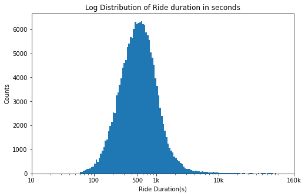

## Distribution of Rider's Age

> Distribution of the rider's age took a right-skewed distribution falling between 20 and 60years. Plotted on a logarithmic scale, the distribution of rider's age takes on a multimodal shape.

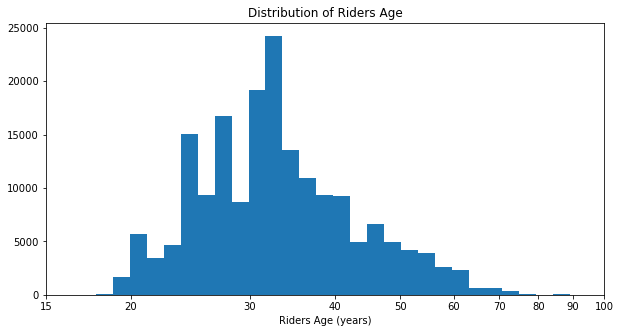

## Average duration covered by weekdays and time of the Day

> Having the lowest rides, the highest avg duration (secs) occured on **Weekends**. Tuesday had the lowest avg duration covered.  
> The longest rides were covered during the **Afternoon**, with the lowest ride covered **morning** which had the highest number of rides taken

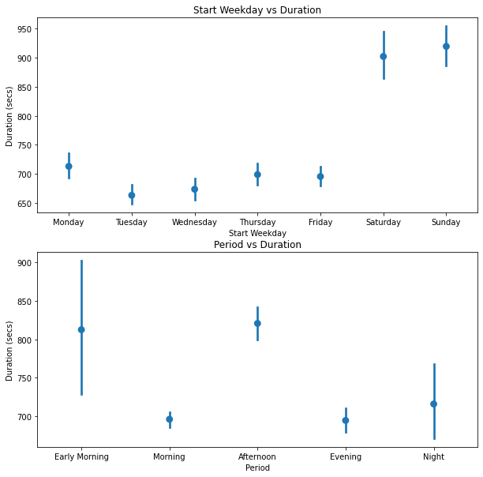

## Correlation between Age and Duration spent by Gender

> There is no correlation between age and duration spend, plotting by Gender

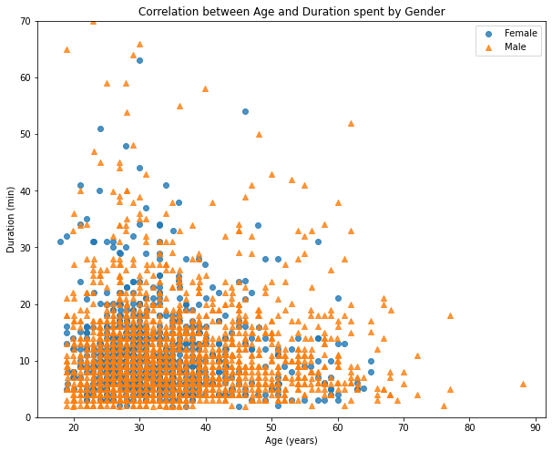

## Average duration taken by each gender at different time of the day

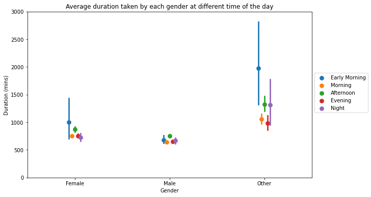